# Reports of Incident Types and Call Origin to Cheshire

Matthew P J Ashby

26/02/2021

This paper examines both the changes in incident types and the changes of call types over time using calls-for-service provided by Cheshire Police. Using data from 2015 to 2020, time series plots were created in order to analysis trends among the first U.K lockdown.

# Changes in Incident Types Over Time

The first part of this report examines the different incident types over time

Each plot is presented with 3 dashed lines that represent; the first known U.K COVID-19 Case, the start of the first U.K lockdown and the end of the first U.K lockdown.

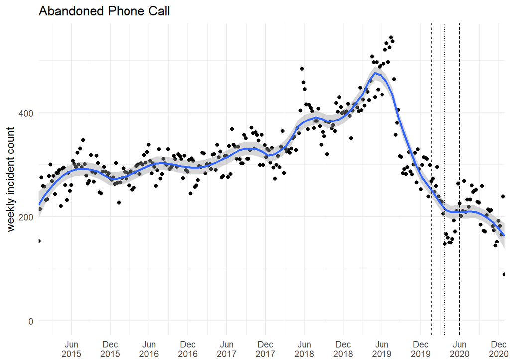

The plot highlights a general increasing trend. Decrease in calls start from around June 2019 and continue until first U.K lockdown, then start to flatten off as lockdown ends.

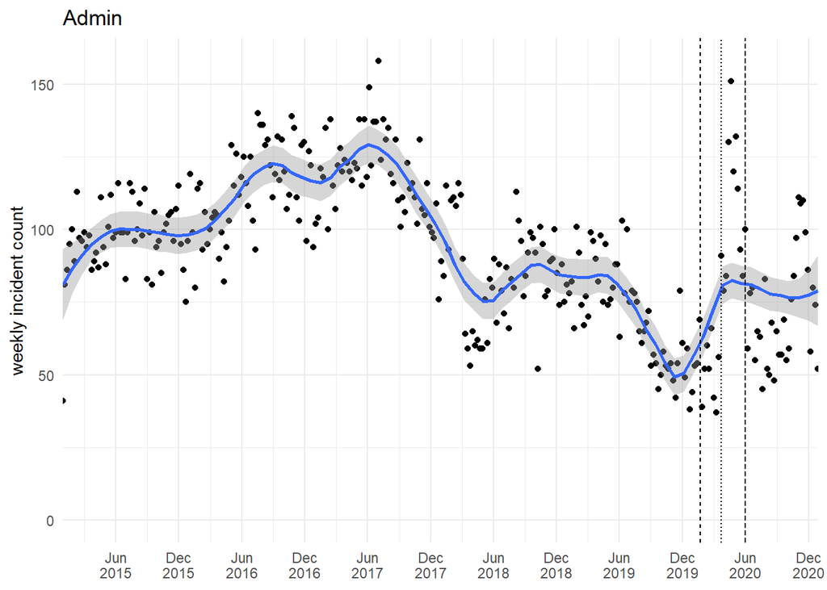

The plot highlights some cyclical movements with a steep increase of admin calls just before first U.K case of COVID-19. However, admin calls then remain relatively flat over the lockdown which could correlate with a decrease of crime reporting over the pandemic.

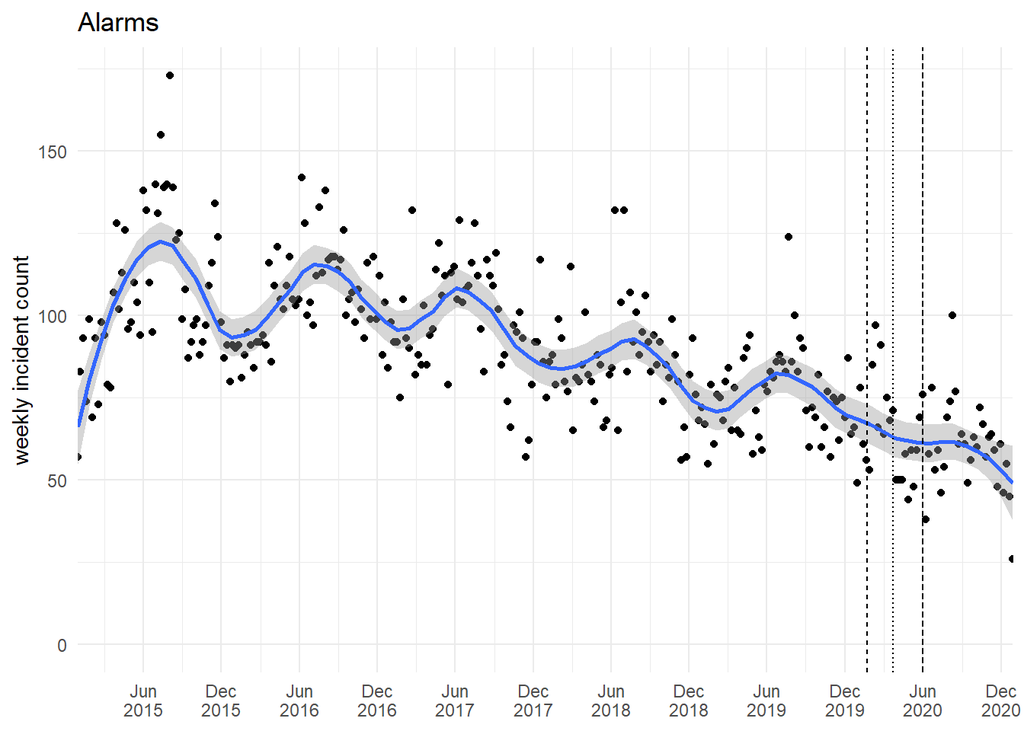

Seasonality is present from 2015 but starts to lose this trend over the lockdown with a steeper decrease in incidents involving activation of alarms. The plot supports criminological theory with more people remaining at home with the closure of retail/businensses.

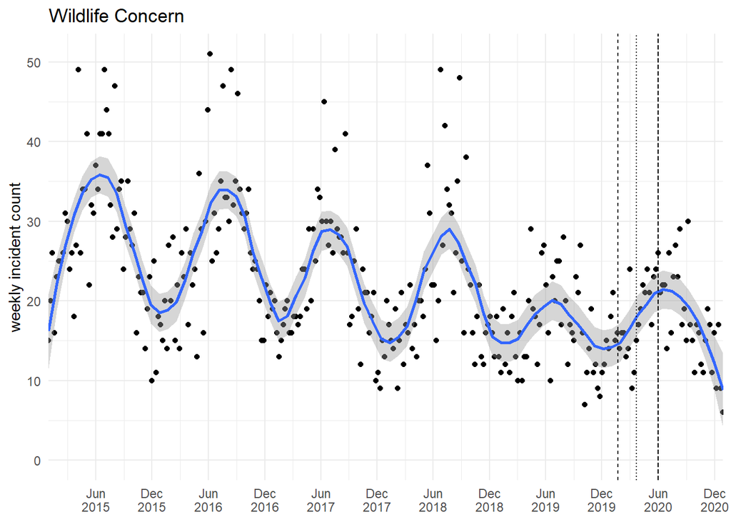

Seasonality is present with a general decrease of wildlife and animal concern, but no noticeable trend.

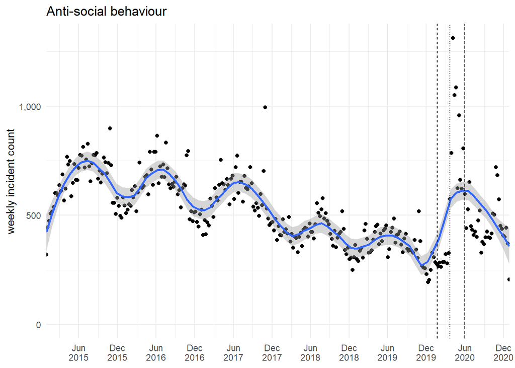

The plot highlights some seasonality with a general decreasing trend. However, there is a sharp increase of ASB from December 2019 to June 2020.

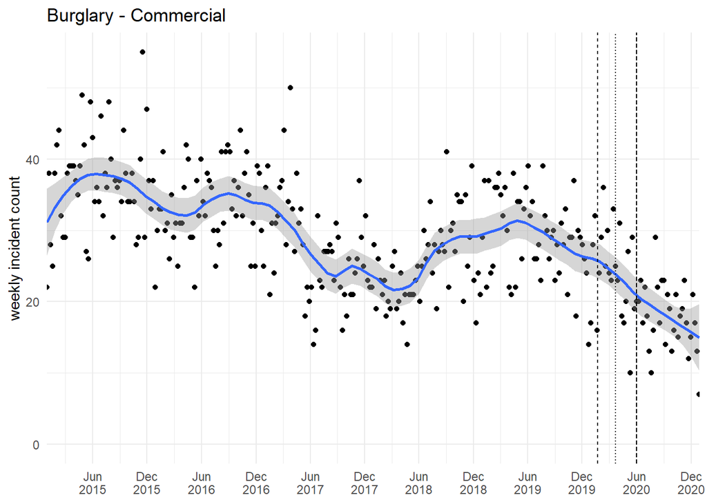

General decrease in commercial burglary over the pandemic. This could be in line with more people working from home and less businesses open. However, there is no clear trend from 2015 so the cause for this decrease is not conclusive.

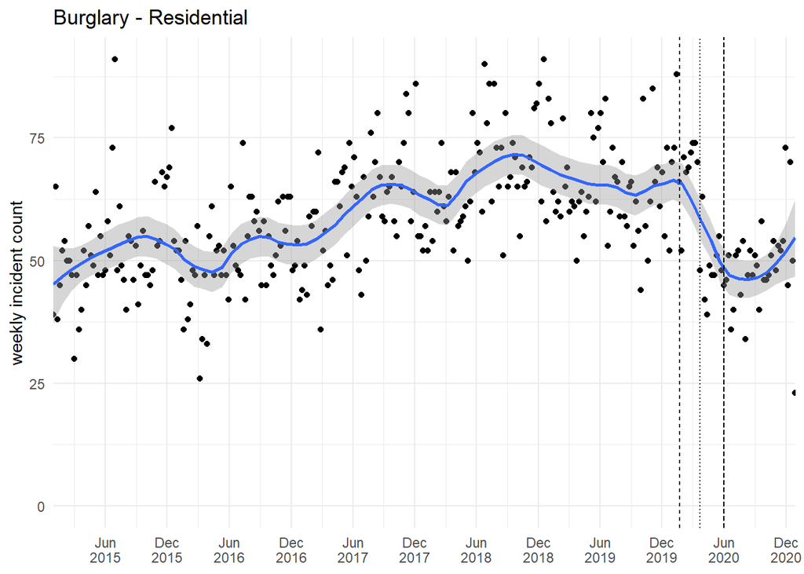

We see a decrease in weekly incident counts over the pandemic but compared to commercial burglary, the patterns no longer follows the upward trend of seasonality. This is what we expect to see due to more people working from home, decreased opportunities and less chance for suitable targets.

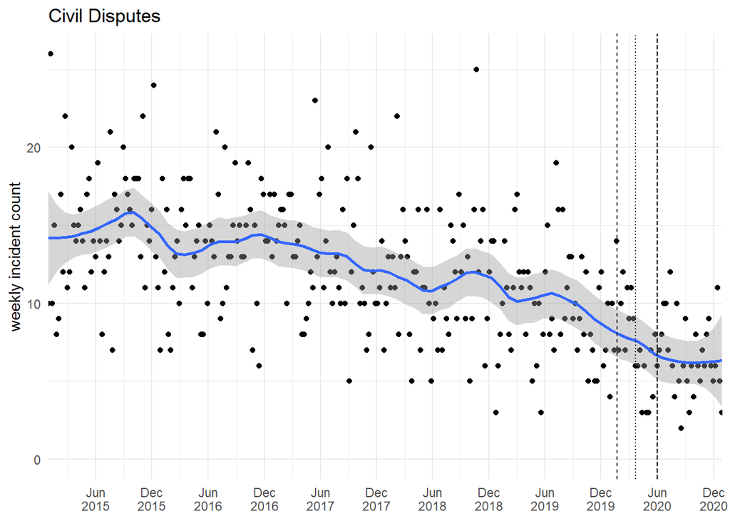

Nothing that notifiable here. Downward trend that arguably flattens out after the lockdown ends.

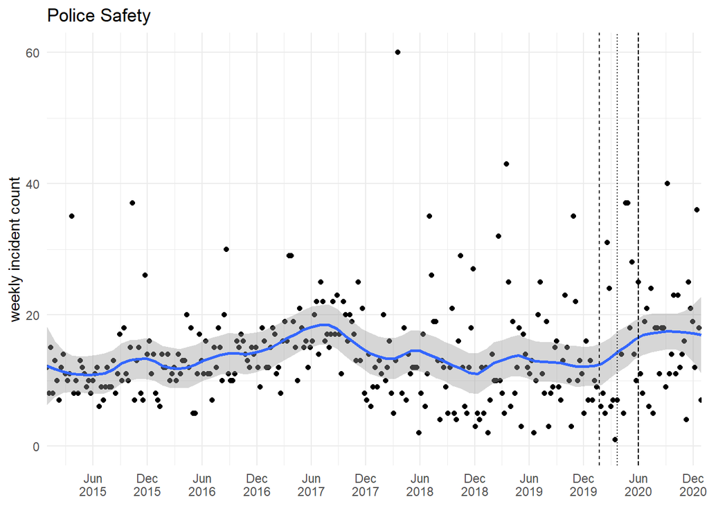

Reports for police safety have increased slightly over the pandemic. Could be reflective of an increase in ASB or the monitoring of people breaking lockdown rules.

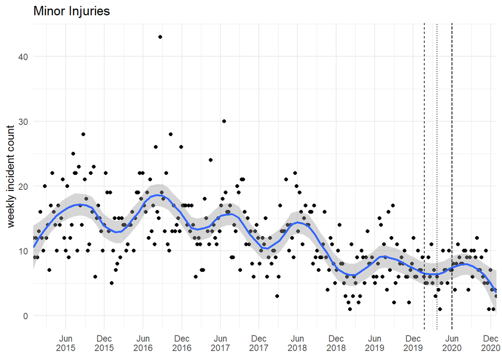

We see a small break in the trend and seasonlity but nothing that significant.

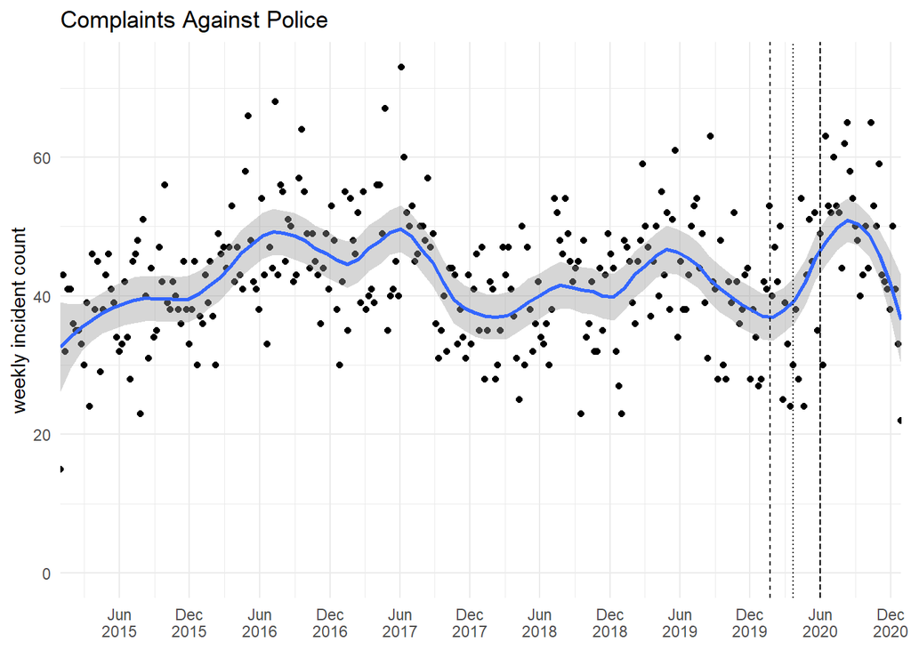

Complaints against the police in the lockdown follow similar cycle patterns. There is a slightly higher peak after the first lockdown ended.

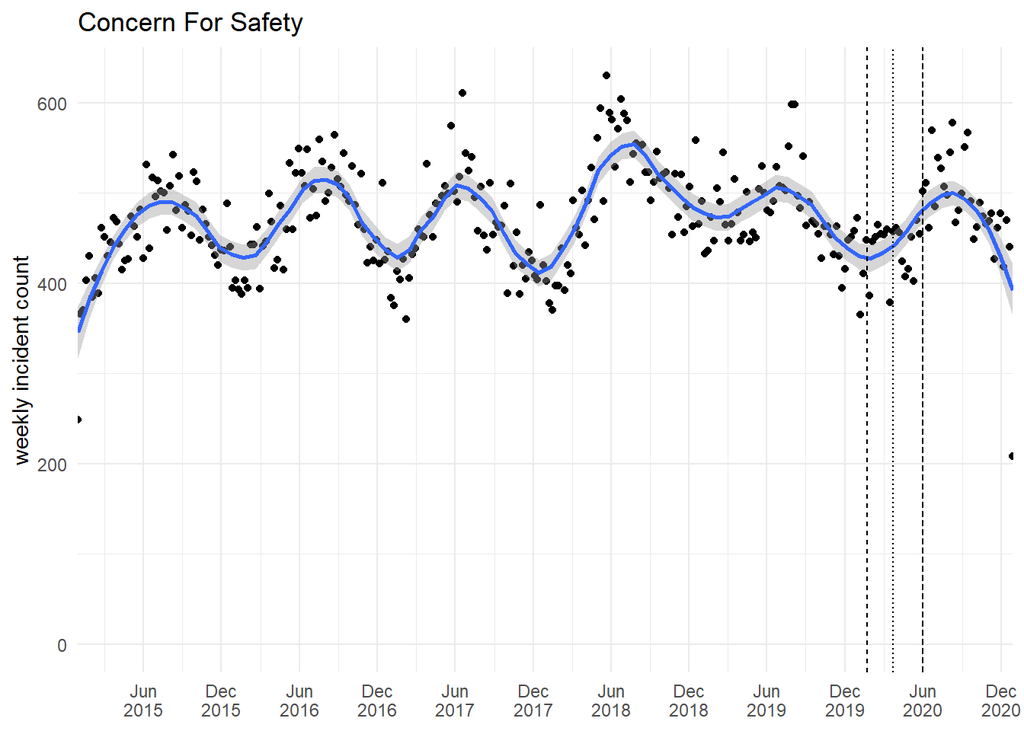

Similar seasonal patterns from before and after the first U.K case with less reporting in December and an increase in summer months.

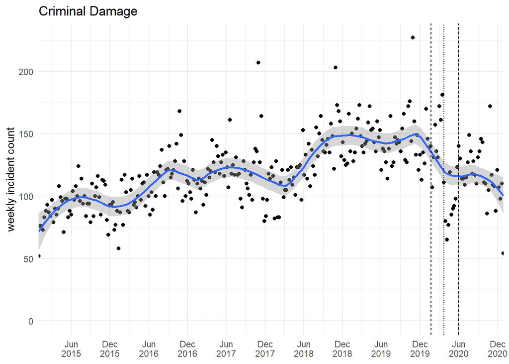

We see that reports of criminal damage decreased as we enter lockdown. This is in line with a change in routine activities as proposed in criminological theory.

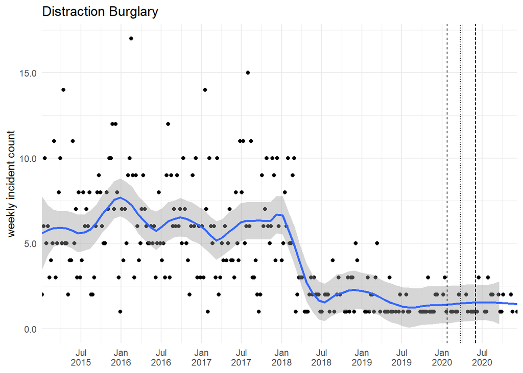

Distraction Bulgary highlights no significant trend in the lockdown.

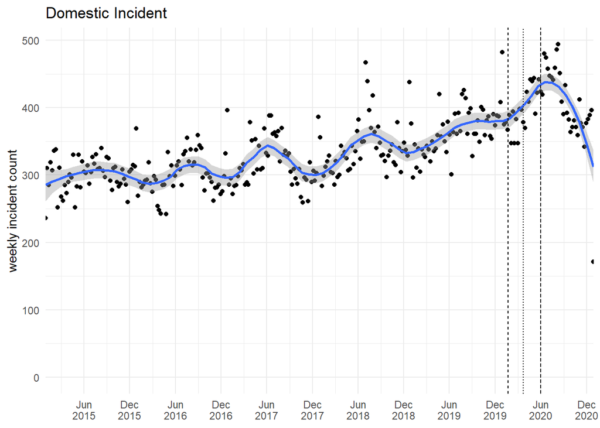

Domestic reports over the lockdown period follows seasonal patterns with an upwards trends. The plot would support literature surrounding an increase in domestic incidents due to the presence of being at home more.

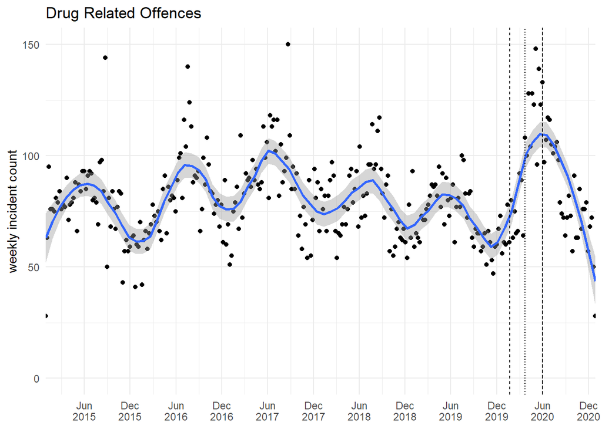

We see similar trends across the years but with a proportionality larger increase of drug related offenses over the lockdown. A fair amount of noise is also present.

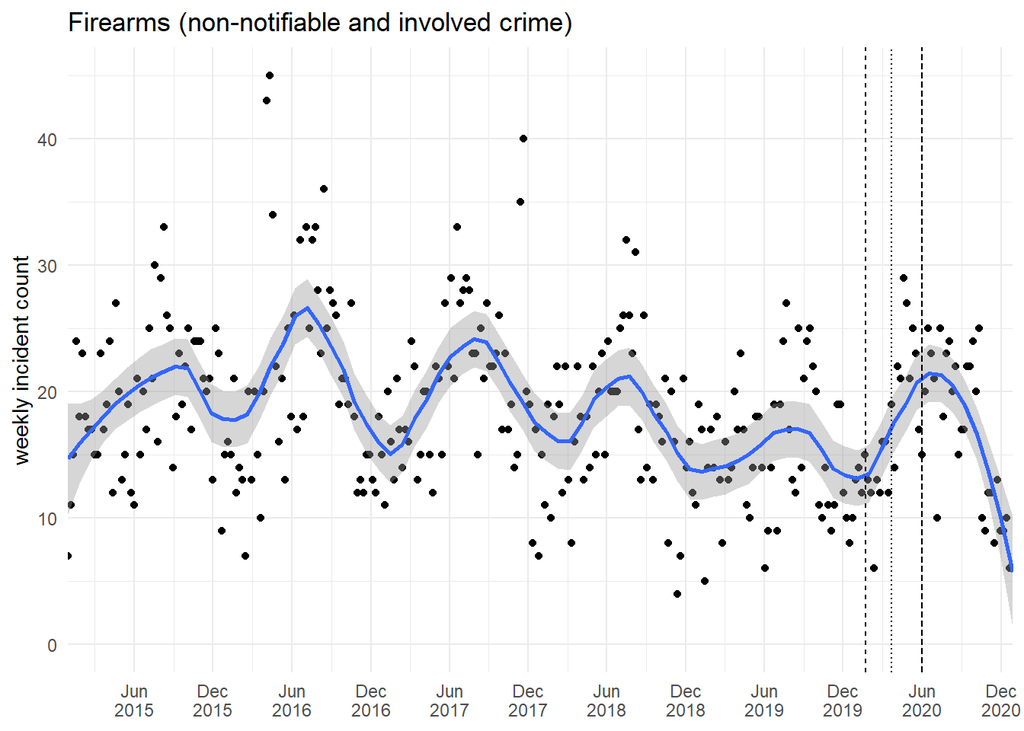

Not much to note here. Some seasonal pattern with some noise.

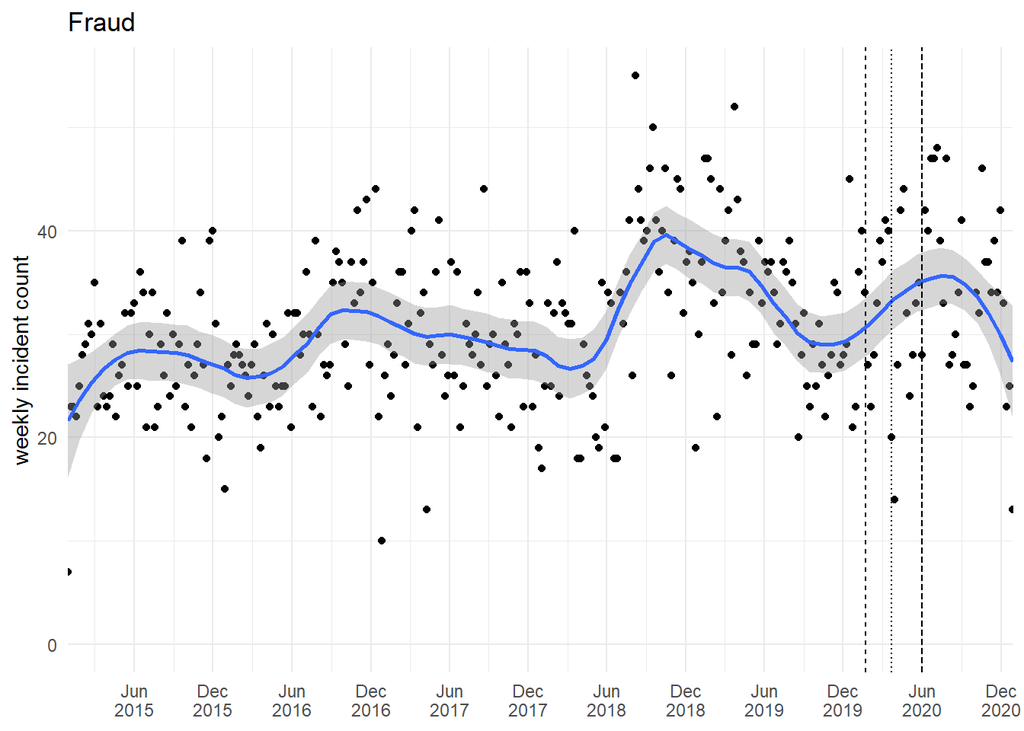

Fraud patterns before 2019 seems to decrease within the December to June months. However, over the December to June months in the lockdown period there is an increase of fraud reports with some noticeable noise

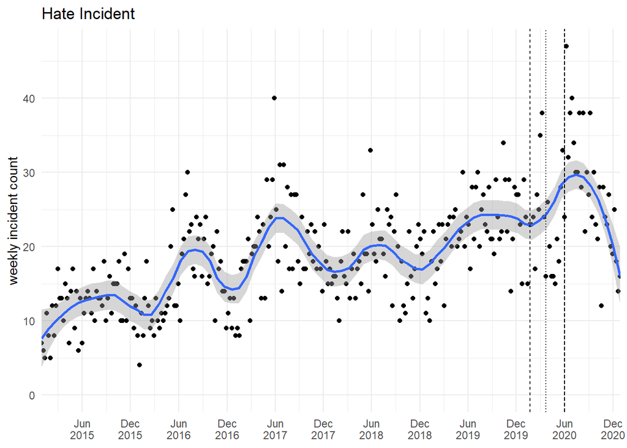

Hate incidents follow the general upward trend with no significant difference within the lockdown. Forecasting will allow us to see whether domestic forecasting is part of a longer cycle.

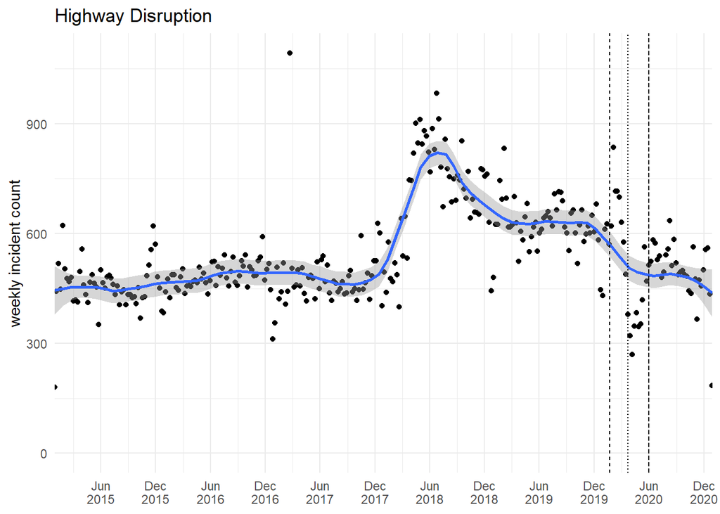

No clear seasonality or trend is present. If anything there is a slight decrease from the start of the lockdown, could be reflective of less people traveling to work due to lockdown restrictions.

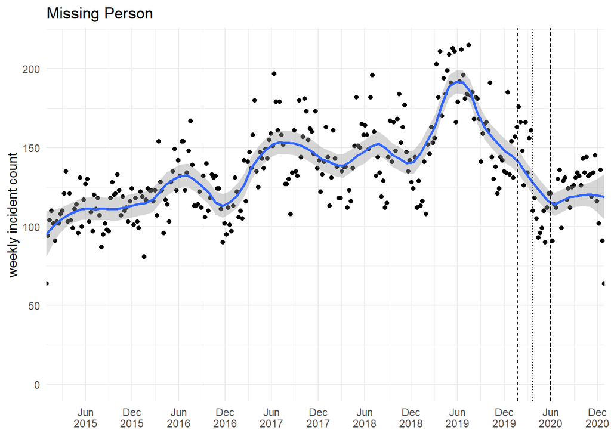

Some noise evident in lockdown period. Why is there such a significant decrease in trend?

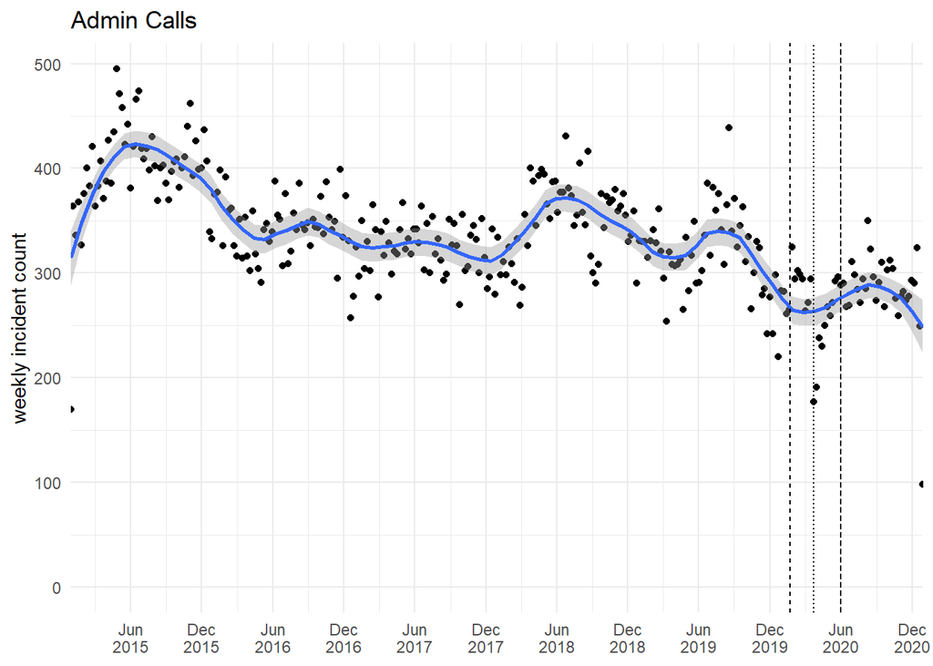

No seasonality within the plot but the overall trend follows a decreasing pattern. Arguable slight increase of Admin Calls over the lockdown period.

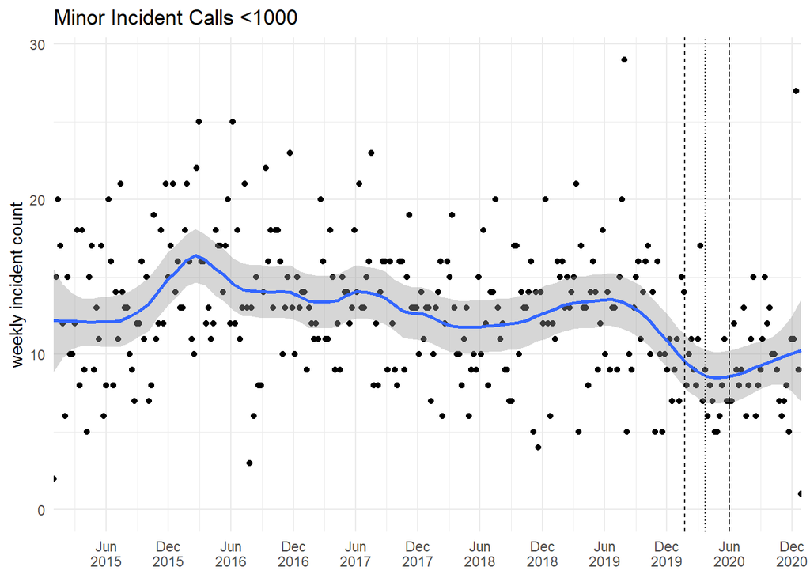

We see a wide distribution of noise throughout the years but a small decrease in minor calls throughout the lockdown period (including; Absconder/AWOL, Cash Vans In Transit, Hoax Call, Iegal Immigrant, Industrial Accident, Kidnap, Licensing, Natural Disaster, OOF Helicopter Deployment, Other Notifiable Crime, Protest/Demonstration, Transport Incident/Accident, Truancy, Vehicle Pursuit, Warrant Crown Court)

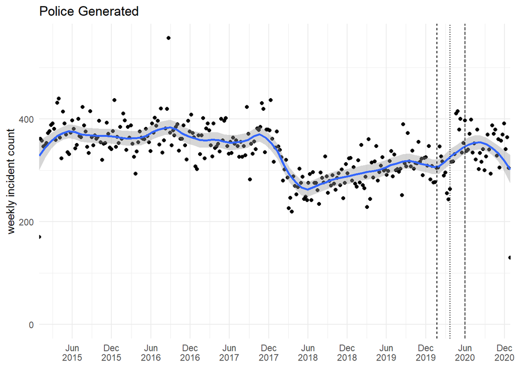

No noticeable trend or seasonality, but there is an increase in police generated responses from the first reported COVID-19 case with an increased proportion of noise.

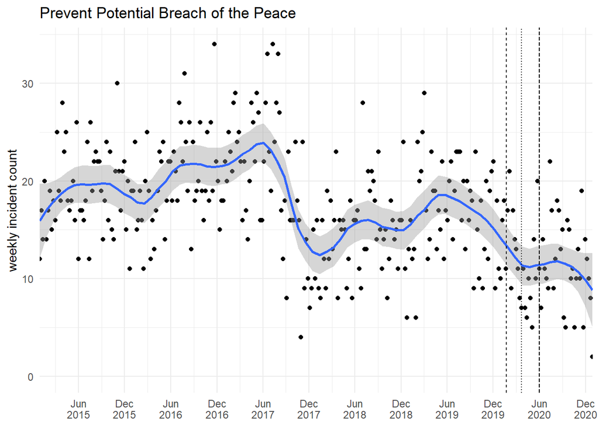

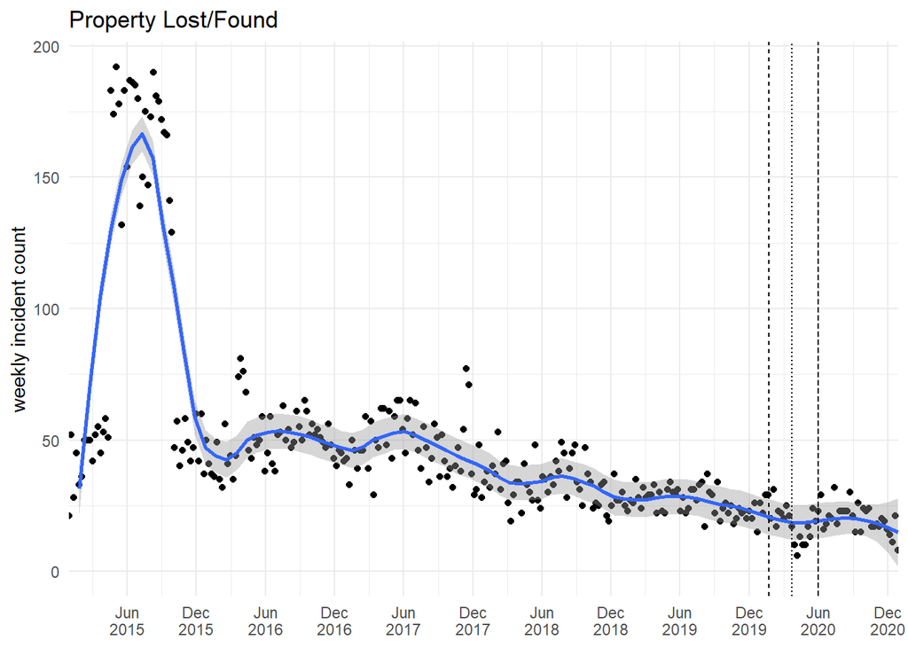

We see a general decreasing trend with no significant cycle or seasonality. There is some noticeable noise after the first U.k lockdown with majority of plots below the average line. Less people present on streets results in less property to be lost/found

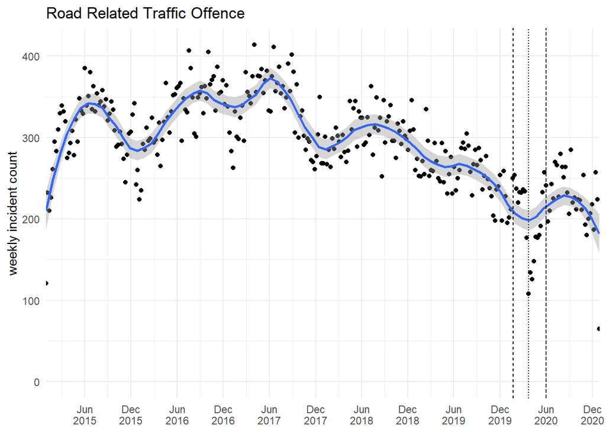

The plot shows some cyclical movement that follows a general decreasing rend. Significant noise/outliers are also present within the lockdown period, again this is what we would expect to see as less people were on the roads due to travel restrictions.

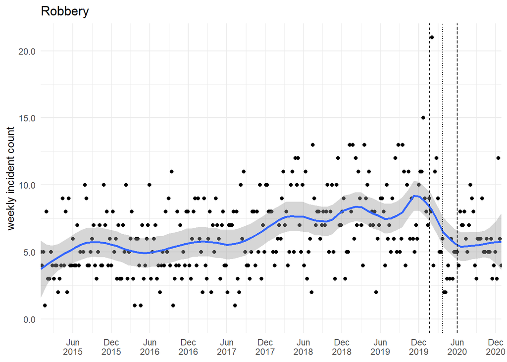

Some season pattern is present. There is also a general increasing trend up until the start of the lockdown where reports of robbery significantly decrease. This is what we expect to have seen where results are grounded in criminological literature; less opportunity to commit crimes.

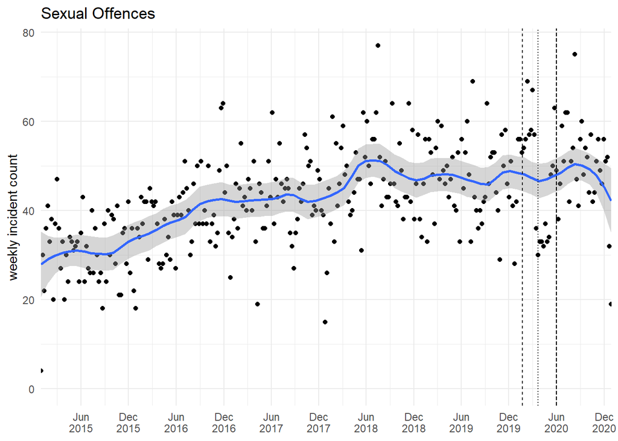

There is a general increasing trend up until the start of the lockdown where the graph shows some cyclical movement, noise is also present. Reports remained fairly high when the first U.K case was announced but then a significant decrease from the first U.K lockdown. After the first lockdown had ended, the trend follows similar pattern to that of previous years.